# Exercise #2

Raffaello Lastrico

14.01.2022

### Data

Analysis based on this timeseries: https://github.com/data-hydenv/data/blob/master/hobo/2022/10_minute/10347366.csv

### Loaded packages

tidyverse, lubridate, hms, zoo, readr

### Preprocessing / R functions

```r
# define function for use in QCP 4
QCP4 <- function(x, threshold){
    if(max(x, na.rm = T) >= threshold){
        return(1)
      }
    else{
        return(0)
      }
}
```

## 1. Quality control procedures (4 QCPs)

```r
# Load data from Github
data <- read_csv(file = "https://raw.githubusercontent.com/data-hydenv/data/master/hobo/2022/10_minute/10347366.csv")
head(data)
```

```
## # A tibble: 6 x 4
##      id dttm                 temp   lux
##   <dbl> <dttm>              <dbl> <dbl>
## 1     1 2021-12-13 00:00:00  6.06     0
## 2     2 2021-12-13 00:10:00  5.96     0
## 3     3 2021-12-13 00:20:00  5.96     0
## 4     4 2021-12-13 00:30:00  5.86     0
## 5     5 2021-12-13 00:40:00  5.86     0
## 6     6 2021-12-13 00:50:00  5.86     0
```

### 1.1 Measurement range (Plausible values) - QCP1

For QCP1 all measurements outside the sensor range will be flagged.

**HOBO Specifications:** Temperature: -20° to 70° C - Light intensity: 0 to 320000 lux

```r
# flag values outside the ranges with 1, those within with 0
data <- data %>%
  mutate(QCP1 = case_when(temp <= 70 & temp >= -20 & lux <= 320000 & lux >= 0 ~ 0,
                          TRUE ~ 1)
        )

# calculate sum of QCP1
sum(data$QCP1)
```

```
## [1] 0
```

**Question**: How many data points are outside the measurement range?

**Answer**: There are 0 data points outside the measurement range of both temperature and light intensity.

### 1.2 Plausible rate of change - QCP2

For QCP2 all data points with more than 1 °K change to the previous measurement are flagged.

```r
# calculate difference in temperature and flag those > 1° C
data <- data %>%
  mutate(var1 = temp - lag(x = temp),
         QCP2 = if_else(abs(var1) > 1, true = 1, false = 0)
         ) %>%
  select(-var1)

# summarise time and count information for QCP2 classification
data %>%
  mutate(daytime = strftime(dttm, format="%H:%M:%S")) %>%
  group_by(QCP2) %>%
  summarise(minTime = min(daytime), maxTime = max(daytime), count = length(daytime))
```

```
## # A tibble: 3 x 4
##    QCP2 minTime  maxTime  count
##   <dbl> <chr>    <chr>    <int>
## 1     0 00:00:00 23:50:00  3799
## 2     1 07:00:00 18:10:00   232
## 3    NA 01:00:00 01:00:00     1
```

**Question**: Describe shortly how many data points failed during this QCP and discuss whether there is a certain daytime pattern of failure or not?

**Answer**: 232 data points failed this quality criterion. 3799 passed. 1 value was assigned NA, due to it being the first point. The measurements that failed all occurred between 7 am and 6:10 pm. This might suggest that larger temperature increases or drops are influenced by sunlight.

### 1.3 Minimum variability (Persistence) QCP3

To pass QCP3 a data point and its 5 previous measurements cannot have the same value. I.e. in any hour period there must be at least two different values measured.

```r
# classify values by QCP3
data <- data %>%
  mutate(QCP3 = case_when(temp == lag(temp, n = 1) & temp == lag(temp, n = 2) &
                          temp == lag(temp, n = 3) & temp == lag(temp, n = 4) &
                          temp == lag(temp, n = 5) ~ 1,
                          is.na(lag(temp, n = 1)) | is.na(lag(temp, n = 2)) |
                          is.na(lag(temp, n = 3)) | is.na(lag(temp, n = 4)) |
                          is.na(lag(temp, n = 5)) ~ NA_real_,
                          TRUE ~ 0)
        )

sum(data$QCP3, na.rm = T)
```

```
## [1] 47
```

```r
# note: with this implementation any hour period containing at least 1 NA value will cause an NA in QCP3. However the analysed time series does not contain NA values, therfore it does not make a difference here.
```

**Task**: Code in this section should analyse the persistence.

*Results:* The time series contains 47 periods of 6 continuous 10-minute intervals with the same value.

### 1.4 Light intensity - QCP4

QCP4 requires all values that were measured while the sensor was in sunshine or bright sunshine to be flagged.

```r
# classify data points by light intensity and period of the day (day/night)
data <- data %>%
  mutate(SIC = case_when(
                lux >= 0 & lux <= 10 ~ "0_night",
                lux >= 10 & lux <= 500 ~ "1_sunrise_sunset",
                lux >= 500 & lux <= 2000 ~ "2_overcast_full",
                lux >= 2000 & lux <= 15000 ~ "3_overcast_light",
                lux >= 15000 & lux <= 20000 ~ "4_clear_sky",
                lux >= 20000 & lux <= 50000 ~ "5_sunshine",
                lux >= 50000 ~ "6_sunshine_bright",
                TRUE ~ "NA"
               ),
         time = as_hms(dttm),
         period = if_else(time >= as_hms("6:00:00") & time <= as_hms("17:59:59"), true = "day", false = "night")
         ) %>%
  relocate(time, period, .after = dttm) %>%
  relocate(SIC, .after = lux)

# Count observations within light intensity classes
data %>% count(SIC)
```

```
## # A tibble: 7 x 2
##   SIC                   n
##   <chr>             <int>
## 1 0_night            2522
## 2 1_sunrise_sunset    333
## 3 2_overcast_full     453
## 4 3_overcast_light    511
## 5 4_clear_sky          13
## 6 5_sunshine           89
## 7 6_sunshine_bright   111
```

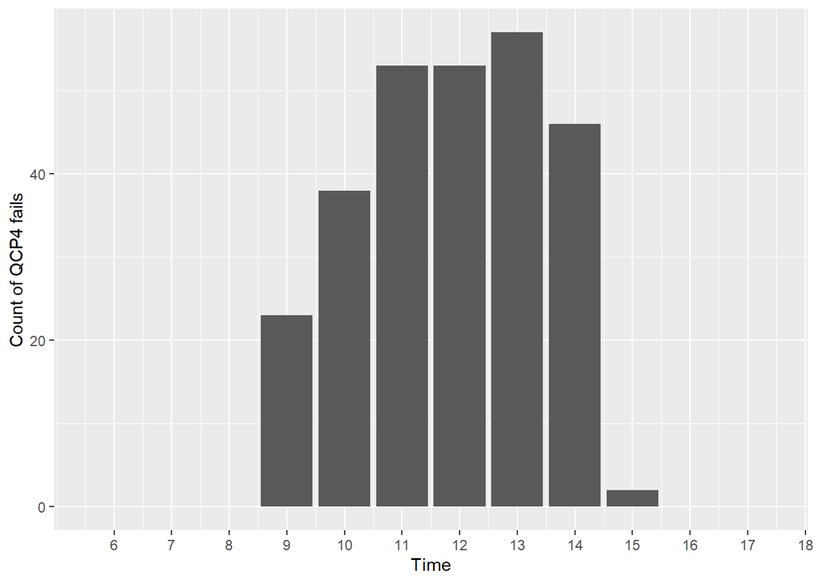

```r
# Implement QCP 4 criterion: flag day time observations >20000 lux (i +- 1); >50000 (i +- 50000)
data <- data %>%
  mutate(QCP4_1 = if_else(period == "day", true = rollapply(lux, width = 3, FUN = QCP4, threshold = 20000, fill = NA, align = "center"), false = 0),
         QCP4_2 = if_else(period == "day", true = rollapply(lux, width = 7, FUN = QCP4, threshold = 50000, fill = NA, align = "center"), false = 0),
         QCP4 = if_else(QCP4_1 + QCP4_2 > 0, true = 1, false = 0)) %>%
  select(-QCP4_1, -QCP4_2)

# Visualize, when the QCP4 criterion fails (which times of day)
data %>%
  filter(period == "day") %>%
  group_by(hour = hour(dttm)) %>%
  summarise(QCP4_Count = sum(QCP4))%>%
  ggplot(aes(x = hour, y = QCP4_Count))+
    geom_col()+
    scale_x_continuous(breaks = seq(6,18, by = 1))+
    xlab("Time")+
    ylab("Count of QCP4 fails")
```

```r
# Calculate total number of fails
data %>%
  count(QCP4)
```

```
## # A tibble: 2 x 2
##    QCP4     n
##   <dbl> <int>
## 1     0  3760
## 2     1   272
```

**Task**: Discuss shortly how often and when during daytime the QCP4 flags bad data. Elaborate on some reasons for your results.

**Answer**: The QCP4 criterion fails mostly around noon (about 150 observations), but never before 9 am or after 3 pm. Over the whole time span 272 observations out of 4032 fail.

## 2. Synthesis

```r
# compare combinations of failures
data %>%
  count(QCP1,QCP2,QCP3,QCP4)
```

```
## # A tibble: 7 x 5
##    QCP1  QCP2  QCP3  QCP4     n
##   <dbl> <dbl> <dbl> <dbl> <int>
## 1     0     0     0     0  3658
## 2     0     0     0     1    90
## 3     0     0     1     0    47
## 4     0     0    NA     0     4
## 5     0     1     0     0    50
## 6     0     1     0     1   182
## 7     0    NA    NA     0     1
```

```r
# calculate sums of failures
data %>%
  select(QCP1:QCP4) %>%
  colSums(na.rm = T)
```

```
## QCP1 QCP2 QCP3 QCP4
##    0  232   47  272
```

**Task**: Present a table or graph to show how many data points fail during the four specific QCPs. Discuss shortly the reasons for failure and compare the different QCPs against each other.

**Answer**: The above output shows, that 3658 10-min observations pass all 4 criteria. QCP1 was always passed, which was to be expected as the sensor only recorded values within its measurement range. QCP2 failed 232 times. QCP3 only failed 47 times. QCP4 failed 272 times, which is to be explained by the sensors position on a south facing wall. This is also mirrored in the QCP2 flags. 182 data points failed both QCP2 and QCP4, which is plausible as sudden changes in cloud cover and sunshine could lead to bigger changes in measured temperature. However later on it might be interesting to further investigate the nature of the 50 QCP2 flags that did not coincide with QCP4 flags. Over the entire time series only 5 values are flagged NA.

## 3. Results

### 3.1 Result (Flagging system: 10-minutes-values)

```r
# create cumulated flags
data <- data %>%
            mutate(QCP_cum = if_else(QCP1 + QCP2 + QCP3 + QCP4 > 0, true = 1, false = 0))

# select required variables
qc_df <- data %>%
            select(id, dttm, temp, lux, QCP1:QCP_cum)

head(qc_df,100)
```

```
## # A tibble: 100 x 9
##       id dttm                 temp   lux  QCP1  QCP2  QCP3  QCP4 QCP_cum
##    <dbl> <dttm>              <dbl> <dbl> <dbl> <dbl> <dbl> <dbl>   <dbl>
##  1     1 2021-12-13 00:00:00  6.06     0     0    NA    NA     0      NA
##  2     2 2021-12-13 00:10:00  5.96     0     0     0    NA     0      NA
##  3     3 2021-12-13 00:20:00  5.96     0     0     0    NA     0      NA
##  4     4 2021-12-13 00:30:00  5.86     0     0     0    NA     0      NA
##  5     5 2021-12-13 00:40:00  5.86     0     0     0    NA     0      NA
##  6     6 2021-12-13 00:50:00  5.86     0     0     0     0     0       0
##  7     7 2021-12-13 01:00:00  5.86     0     0     0     0     0       0
##  8     8 2021-12-13 01:10:00  5.86     0     0     0     0     0       0
##  9     9 2021-12-13 01:20:00  5.76     0     0     0     0     0       0
## 10    10 2021-12-13 01:30:00  5.66     0     0     0     0     0       0
## # ... with 90 more rows
```

**Task**: At the end of the code section above you should generate one! tibble or data.frame named `qc_df` with all time information, all data points (temperature and lux) and your outcomes of the different QCPs.

### 3.2 Result (Aggregate to hourly series)

```r
# create qrouping variable
qc_df <- qc_df %>%
            mutate(day_hour = ymd_h(format(dttm, format = "%Y-%m-%d %H")))

# aggregate qc_df to hourly values (condition: not more than 1 QCP_cum failure per hour)
hobo_hourly <- qc_df %>%
            group_by(day_hour) %>%
            summarise(temp = if_else(sum(QCP_cum, na.rm = T) <= 1, true = round(mean(temp), 4), false = NULL)) %>%
            rename(dttm = day_hour)

head(hobo_hourly, 50)
```

```
## # A tibble: 50 x 2
##    dttm                 temp
##    <dttm>              <dbl>
##  1 2021-12-13 00:00:00  5.93
##  2 2021-12-13 01:00:00  5.71
##  3 2021-12-13 02:00:00  5.59
##  4 2021-12-13 03:00:00  5.16
##  5 2021-12-13 04:00:00  4.57
##  6 2021-12-13 05:00:00  3.82
##  7 2021-12-13 06:00:00  3.35
##  8 2021-12-13 07:00:00  3.26
##  9 2021-12-13 08:00:00  3.08
## 10 2021-12-13 09:00:00 NA
## # ... with 40 more rows
```

**Task**: At the end of the code section above you should generate one! tibble or data.frame named `hobo_hourly` with averaged temperature values per hour or NA values (if the hour is flagged as bad data). See exercise description for more details.

- First column: YYYY-DD-MM HH:MM:SS
- Second column: Temperature values (4 digits), NA values possible